# Ejercicio de Clase - Creditos - Notas 3 - pag 43

### Paquetes requeridos para correr el ejercicio

```r
install.packages("R2OpenBUGS")
install.packages("R2jags")
library(R2OpenBUGS)
library(R2jags)

#-Working directory-
wdir<-"/Users/guillemontanari/ITAM/github/GLM2016/JAGS-Ejercicio1"
setwd(wdir)
```

### 2) Las utilidades mensuales de una compañía tienen una distribución Normal(Mu, Sigma Cuadrada)

Ponga que una muestra de 10 meses de esta compañía dio como resultado las siguientes utilidades: (212, 207, 210, 196, 223, 193,196, 210, 202, 221).

Esto quiere decir que tengo como INFORMACION INICIAL lo siguiente:

$x1,...,xn$ es una m.a. 10 meses con determinados valores dados

$n=10$ la muestra que tengo hoy de las utilidades mensuales.

#### a) La incertidumbre sobre la utilidad promedio anual se puede representar por una distribución N(200,40), y la incertidumbre de la desviación estándar de las utilidades mensuales se puede representar mediante una distribución Ga(10,1).

Mediante la distribución posterior estima $\mu$ y $\sigma^2$

```r
#-Reading data-
utilidad<-c(212, 207, 210,196, 223, 193,196, 210, 202, 221)
n<-length(utilidad)

# Media Muestral es 207 y Desvio Std 10.32

#-Defining data-
data<-list("n"=n,"x"=utilidad)

#-Defining inits-
inits<-function(){list(mu=0,sig=1,x1=0)}

#-Selecting parameters to monitor-
parameters<-c("mu","sig","x1")

#-Running code-
#JAGS
ej2a.sim<-jags(data,inits,parameters,model.file="Ej2_a.txt",
              n.iter=5000,n.chains=1,n.burnin=500,n.thin=1)
```

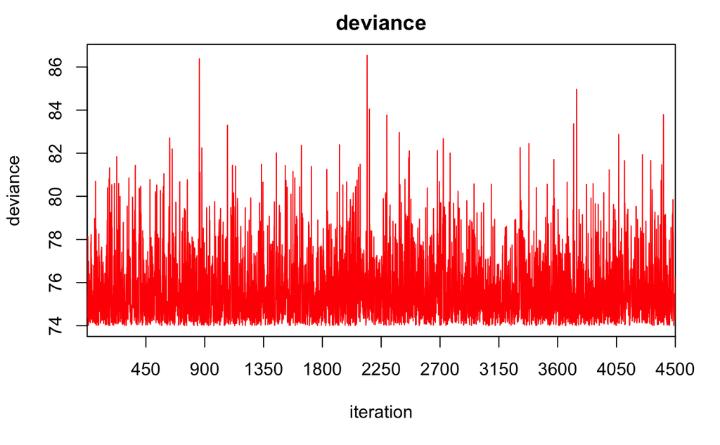

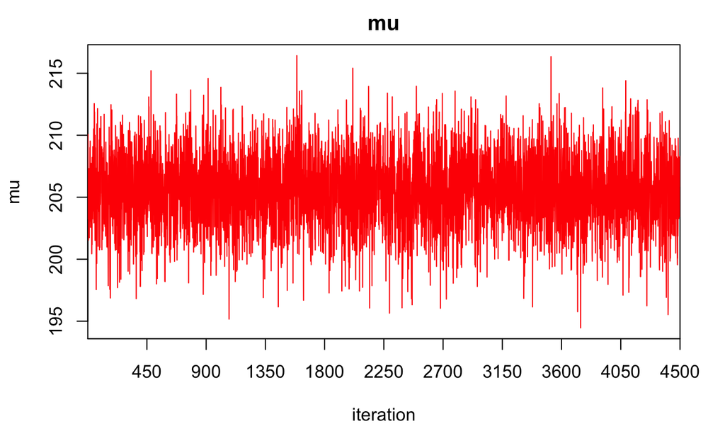

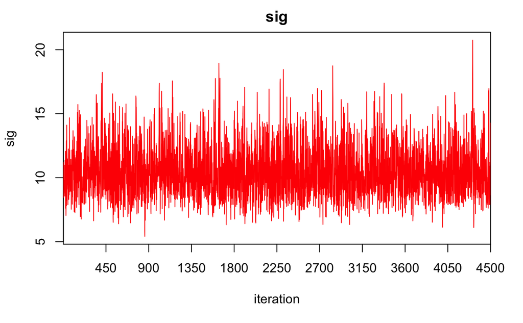

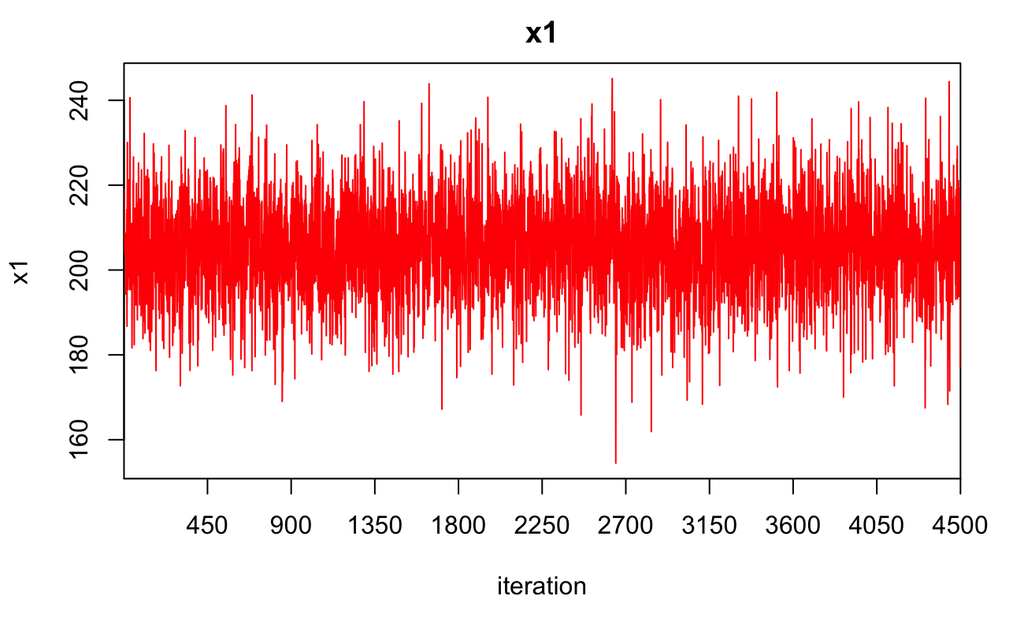

```r
#-Monitoring chain-
#Traza de la cadena
traceplot(ej2a.sim)
```

```r
#Cadena
#JAGS
out<-ej2a.sim$BUGSoutput$sims.list
z<-out$x1
par(mfrow=c(2,2))
plot(z,type="l")
plot(cumsum(z)/(1:length(z)),type="l")
```

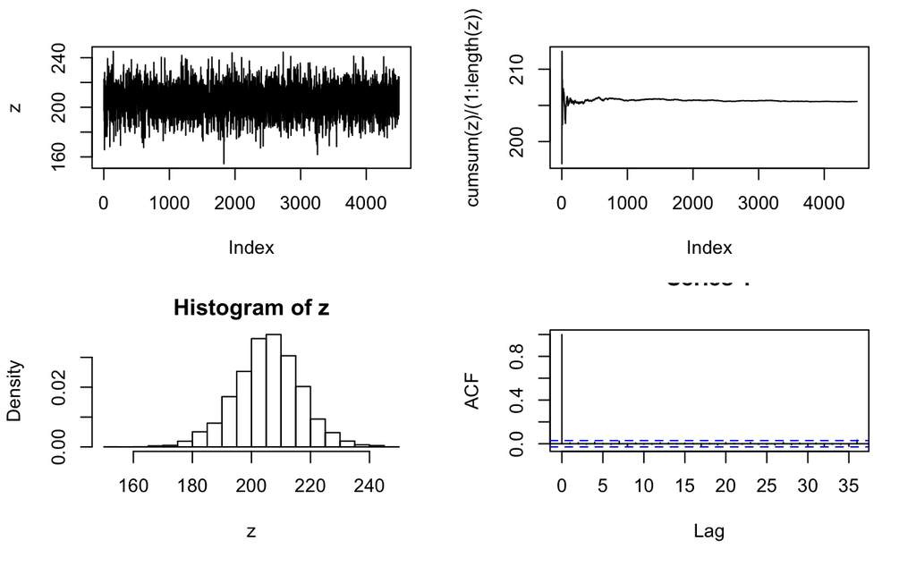

```r
hist(z,freq=FALSE)
acf(z)
```

Primer cuadro: como se está moviendo theta

Segundo: como esta convergiendo o no la media. Si se mueve mucho necesito mas iteraciones.

Tercero: Histograma de mi posterior. Si tengo “huecos” entonces necesito mas iteraciones porque hay espacios de mi parámetro que no estoy recorriendo

Cuarto: Correlacion entre las variables simulados. En este caso es 0 (dos rayas azules muy pegadas a cero)

```r
#Resumen (estimadores)
#JAGS
out.sum<-ej2a.sim$BUGSoutput$summary
print(out.sum)
```

```
              mean        sd       2.5%        25%       50%       75%     97.5%
deviance  75.64398  1.572599  74.043371  74.486192  75.14788  76.34489  79.73453
mu       205.51148  2.967721 199.601381 203.580880 205.55292 207.46730 211.32531
sig       10.55232  1.993476   7.420002   9.149842  10.27806  11.71474  15.09596
x1       205.54337 11.146347 182.348741 198.635436 205.71479 212.77896 227.39157
```

```r
#DIC
#JAGS
out.dic<-ej2a.sim$BUGSoutput$DIC
print(out.dic)
```

```
[1] 76.88051
```

ESTE RESUMEN ME DICE

RESULTA EN:

En este caso la distribucion final tiene una distribucion final: media 205, sigma 10.

- DIC: es la medida del error del modelo. Cuanto más chico mejor.

[output not shown]